# Desvendando o Resultado do Tesouro Nacional

```r
library(xlsx)
library(XLConnect)
library(tidyr)

URL_add<-"http://www.tesourotransparente.gov.br/ckan/dataset/ab56485b-9c40-4efb-8563-9ce3e1973c4b/resource/527ccdb1-3059-42f3-bf23-b5e3ab4c6dc6/download/Anexos-RTN-Dez-2017.xlsx"
tmp = tempfile(fileext = ".xlsx")
library(RCurl)


download.file(URL_add,mode = "wb", destfile = tmp)
rtn_geral <- read.xlsx(tmp, sheetIndex=2, rowIndex = c(5:79))
names(rtn_geral)[1]<-"Rubrica"
series_temporais_analise<-gather(rtn_geral,Data, Valor,-Rubrica)
series_temporais_analise$Data<-gsub("X","",series_temporais_analise$Data)
series_temporais_analise$Data<-as.Date(as.numeric(series_temporais_analise$Data), origin="1899-12-30")
rm(rtn_geral)
save(list = ls(),file = "todas_series.Rdata")
rm(series_temporais_analise)
```

# Visão Geral

As estatísticas fiscais demonstram os resultados da gestão fiscal e são, portanto, instrumentos para a transparência, tomada de decisão ou mesmo de participação e controle social. A STN – por meio do RTN – apura o resultado a partir da mensuração dos fluxos de ingressos (receitas) e saídas (despesas), conforme metodologia conhecida como “acima da linha”. A estatística fiscal “acima da linha” permite ao gestor público avaliar os resultados da política fiscal corrente por meio de um retrato amplo e detalhado da situação fiscal do país. Esse conjunto de informações constitui um ferramental essencial para as tomadas de decisões em termos de políticas públicas

# Resultado Nominal e Primário

O resultado nominal é o conceito fiscal mais amplo e representa a diferença entre o fluxo agregado de receitas totais (inclusive de aplicações financeiras) e de despesas totais (inclusive despesas com juros), num determinado período. Essa diferença corresponde à necessidade de financiamento. O resultado primário relaciona o esforço fiscal do período e a variação da dívida líquida, já que as despesas líquidas com juros refletem déficits primários do passado. Se o governo gasta menos do que arrecada, desconsiderando a apropriação de juros sobre a dívida líquida existente, há superávit primário. Este superávit pode contribuir para uma redução dos passivos, uma elevação dos ativos ou uma combinação de ambos.O RTN apura o resultado fiscal do Governo Central pelo conceito de resultado primário.

## Análise do Resultado Primário

Como já foi dito o resultado primário trata-se da diferença entre receitas e despesas primárias, Quando essa diferença positiva, tem-se um superávit primário e no caso contrário um défict primário. Pela estrutura do RTN, o Resultado Primário é caluclado pela seguinte fórmula:

$$RP = RL - DT + FSB$$
Onde: RP = Resultado Primário
RL = Receita Líquida
DT = Despesa Total
FSB = Resultado do Fundo Soberano do Brasil

O gráfico abaixo mostra a evolução das séries relacionadas à fórmula do Resultado Primário. Observe o comportamento da série RP, procurando identificar os pontos onde os valores são positivos e negativos. Para esses pontos busque os valores das séries RL e DT, principalmente para verificar como a diferença entre essas duas séries estpa gerando superávits e déficits primários. Experimente mover as setas abaixo do gráfico para esquerda ou para direita para analisar com mais foco algum período específico.

```r
load("todas_series.Rdata")
serie_trabalho <- series_temporais_analise[grep("VI. PRIM",series_temporais_analise$Rubrica),]
serie_trabalho <- rbind(serie_trabalho,series_temporais_analise[grep("III. RECEITA",series_temporais_analise$Rubrica),])
serie_trabalho <- rbind(serie_trabalho,series_temporais_analise[grep("IV. DESPESA TOTAL",series_temporais_analise$Rubrica),])
serie_trabalho <- rbind(serie_trabalho,series_temporais_analise[grep("V. FUNDO SOBERANO DO BRASIL",series_temporais_analise$Rubrica),])

rm(series_temporais_analise)

ano_fim<-as.numeric(substr(serie_trabalho$Data[NROW(serie_trabalho)],1,4))
mes_fim<-as.numeric(substr(serie_trabalho$Data[NROW(serie_trabalho)],6,7))
ts_serie_trabalho_prim <- ts(serie_trabalho$Valor[grep("VI. PRIM",serie_trabalho$Rubrica)],start = c(1997,1),end = c(ano_fim,mes_fim),frequency = 12)
ts_serie_trabalho_rec  <- ts(serie_trabalho$Valor[grep("III. RECEITA",serie_trabalho$Rubrica)],start = c(1997,1),end = c(ano_fim,mes_fim),frequency = 12)
ts_serie_trabalho_desp  <- ts(serie_trabalho$Valor[grep("IV. DESPESA TOTAL",serie_trabalho$Rubrica)],start = c(1997,1),end = c(ano_fim,mes_fim),frequency = 12)
ts_serie_trabalho_fsb  <- ts(serie_trabalho$Valor[grep("V. FUNDO SOBERANO DO BRASIL",serie_trabalho$Rubrica)],start = c(1997,1),end = c(ano_fim,mes_fim),frequency = 12)
ts_serie_trabalho_fsb[ts_serie_trabalho_fsb==0]<-NA
save(list = ls(),file = "serie_trabalho_prim.Rdata")
y_min <- min(as.numeric(serie_trabalho$Valor))
y_max <- max(as.numeric(serie_trabalho$Valor))
rm(serie_trabalho)
series <-cbind(ts_serie_trabalho_prim,ts_serie_trabalho_rec,ts_serie_trabalho_desp,ts_serie_trabalho_fsb)

library(dygraphs) #Série temporal dinâmica


dygraph(series,main = "Resultado Primário - Governo central") %>%
  dyRangeSelector() %>%
  dyAxis(name= "y",valueRange = c(y_min,y_max)) %>%
  dySeries(label = "RP") %>%
  dySeries(label = "RL") %>%
  dySeries(label = "DT") %>%
  dySeries(label = "FSB") %>%
  dyLegend(show = "always", hideOnMouseOut = TRUE, width = 400)%>%
  dyOptions(connectSeparatedPoints = TRUE)%>%
  dyHighlight(highlightCircleSize = 5,
              highlightSeriesBackgroundAlpha = 0.2,
              hideOnMouseOut = FALSE)
```

[interactive chart not shown]

Como pode ser observado no gráfico, ocoreram superávits primários em Novembro de 2013 e em Outubro de 2017, por exemplo. Nota-se nesses casos que a Receita Líquida foi superior à Despesa Total, enquanto que o valor do fluxo de Fundo Soberano estava zerado. O contrário ocorreu, por exemplo, em Agosto de 2014 e Setembro de 2017, gerando dessa forma déficits primários.

```r
load("serie_trabalho_prim.Rdata")
write.csv2(serie_trabalho, "./file.csv")

library(magrittr)
readLines("./file.csv") %>%
  paste0(collapse="\n") %>%
  openssl::base64_encode() -> encoded
rm(serie_trabalho)
```

## Gráfico do Resultado Primário

O gráfico abaixo mostra a evolução temporal do resultado primário em valores nominais.

```r
dygraph(ts_serie_trabalho_prim,main = "Resultado Primário - Governo central") %>%
dyRangeSelector() %>%
dyAxis(name= "y",valueRange = c(min(as.numeric(ts_serie_trabalho_prim)),max(as.numeric(ts_serie_trabalho_prim))))
```

[interactive chart not shown]

## Gráficos Avançados do Resultado Primário

Os dados da série podem ser analisados através de seus componentes de tendência, sazonalidade e valores remanescente. O gráfico abaixo mostra essa possibilidade

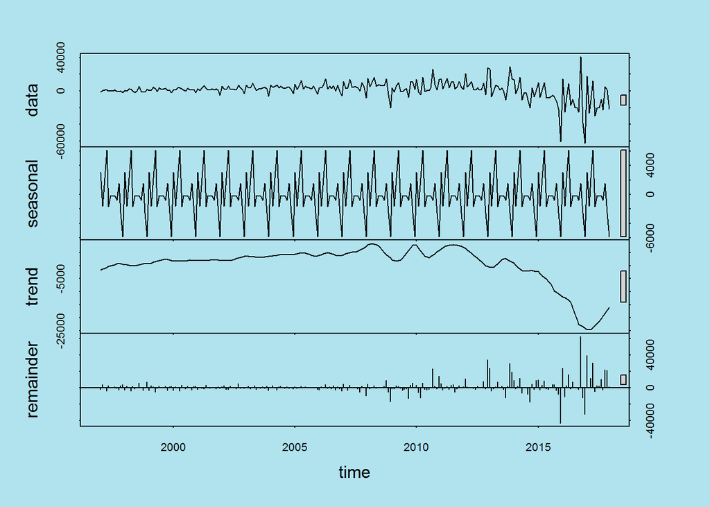

```r
grafico<-ts_serie_trabalho_prim %>%
  stl(t.window=13, s.window="periodic", robust=TRUE)

par(bg="#b1e3ef")

plot(grafico)
```

# RTN - Sintético

```r
GraficoSerieRTN <- function(rubrica, series_temporais_analise){

  library(dygraphs)


  mes_fim<-as.numeric(substr(series_temporais_analise$Data[nrow(series_temporais_analise)],6,7))
  ano_fim<-as.numeric(substr(series_temporais_analise$Data[nrow(series_temporais_analise)],1,4))
  ts_serie_trabalho<- ts(series_temporais_analise$Valor[grep(rubrica,series_temporais_analise$Rubrica)],start = c(1997,1),end = c(ano_fim,mes_fim),frequency = 12)



   dygraph(ts_serie_trabalho,main = rubrica) %>%
     dyRangeSelector() %>%
     dyAxis(name= "y",valueRange = c(min(as.numeric(ts_serie_trabalho)),max(as.numeric(ts_serie_trabalho))))


}

load("todas_series.Rdata")
varNames <- series_temporais_analise$Rubrica[which(!duplicated(series_temporais_analise$Rubrica))]

library(manipulateWidget)
library(shiny)

shinyApp(

  ui = fluidPage(
    selectInput("rubricas", "Rubricas",
                choices = varNames),
    plotOutput("rubricaPlot")
  ),

  server = function(input, output) {
    output$rubricaPlot <- renderPlot({
      GraficoSerieRTN(rubrica,series_temporais_analise)
    })
  },

  options = list(height = 500)
)
```

```r
# ui <- fluidPage(
#   plotOutput("plot"),
#
#   rubrica = mwSelect(varNames)
#
# )
#
# server <- function(input, output, session) {
#   output$plot <- renderPlot(GraficoSerieRTN(rubrica,series_temporais_analise) )



#shinyApp(ui, server)
#runApp(app)

# shinyApp(
#   ui=manipulateWidget(
#   GraficoSerieRTN(rubrica,series_temporais_analise),
#   rubrica = mwSelect(varNames),
#     .viewer="window"),
#   server =
#   options = list(height = 500))
#
# runApp(manipulateWidget(
#    GraficoSerieRTN(rubrica,series_temporais_analise),
#    rubrica = mwSelect(varNames),
#      .viewer="window"))
```

# Todas as receitas

# Todas as despesas